> Dr. Baggett is an excellent instructor and a subject matter expert. His teaching style is unique to him; he makes things easier to understand with real life scenarios. He answers questions outside of class time and is easily approached for more guidance and information. I’d happily take another one of Dr. Baggett’s courses.

Following the successful defense of my Ph.D. dissertation in the Fall semester of 2014, I was promoted from Instructor to Assistant Professor of Psychology. Thus, my tenure and promotion timeline began in the Fall semester of 2015. However, in the interest of completeness I have included and linked to all student evaluations of teaching (SET) I received at UMHB during the semesters prior to Fall 2015.

As I previously stated in the Teaching Methods and Teaching Responsibilities sections of my portfolio, I certainly feel much more “at home” within the confines of quantitative psychology. However, it is rewarding to occasionally take a semester and dive deeper into the panoply of fascinating and complex ideas and issues within the discipline of psychology. That said, over the course of the last seven years I have taught a combination of nine different undergraduate and graduate courses a total of 63 times[^1]. Of those nine, three were electives and accounted for only five of my total of 63. All 58 other offerings were comprised of required undergraduate and graduate courses.

Moreover, PSYC 2314: Research Methods for the Social Sciences and PSYC 2316: Statistics for the Social Sciences account for over 70% (*n* = 45) of the courses I have offered during my time at UMHB. Clearly, these two are chief among my relative expertise and interests. Therefore, if I may, I would prefer to devote the majority of my writing in this section toward addressing PSYC 2314 and PSYC 2316.

### Overall Quantitative IDEA Data

Starting with the whole of my teaching record and student evaluations of teaching, my IDEA composite scores ranged from a low of 29 in the Fall of 2014 (the semester in which I completed and defended my Ph.D. dissertation while simultaneously teaching 12 hours) to a high of 71 during the Spring of 2016. The boxplot below, specifically the red shaded portions, displays the SET scores, from left to right, at the 25th percentile (50), 50th percentile (56.5), and 75th percentile (59.75), respectively. Additionally, two statistical outliers are present: the aforementioned 29 and a 36 from PSYC 4316: Experimental Psychology during the Spring of 2019. My maternal grandfather, with whom I was very close, passed away that January. Admittedly, and as a result, I was not as organized or prepared for PSYC 4316 that semester as I would have preferred.

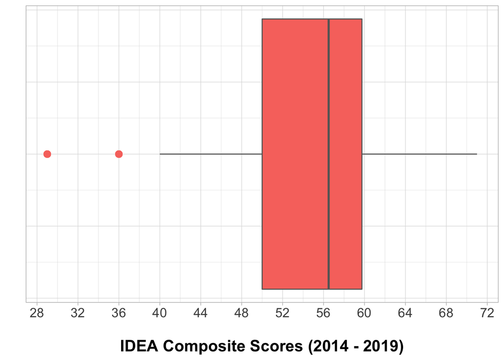

Frequency Count of IDEA Composite Score Comparison Category

| Category | N |
| --- | --- |
| Lower (Next 20%) | 6 |
| Similar (Middle 40%) | 15 |
| Higher (Next 20%) | 18 |
| Much Higher (Highest 10%) | 7 |

Note: Two outliers removed.

**1. PSYC 2314: Research Methods for the Social Sciences**  
The table below contains the IDEA composite scores for the 12 semesters I have taught PSYC 2314 for which IDEA reports were generated. Of these 12, multiple sections were taught 6 times. In these instances, a mean of the two IDEA composite scores is provided.

Mean PSYC 2314 IDEA Composite Scores by Term

| Term | Course | IDEA Score | Category |
| --- | --- | --- | --- |
| Spring 2019 | PSYC 2314 | 62 | Higher (Next 20%) |
| Fall 2017 | PSYC 2314 | 61 | Higher (Next 20%) |
| Fall 2016 | PSYC 2314 | 59 | Higher (Next 20%) |
| Fall 2018 | PSYC 2314 | 58 | Higher (Next 20%) |
| Fall 2015 | PSYC 2314 | 56 | Higher (Next 20%) |
| Spring 2017 | PSYC 2314 | 53 | Similar (Middle 40%) |
| Fall 2019 | PSYC 2314 | 52 | Similar (Middle 40%) |
| Spring 2014 | PSYC 2314 | 51 | Similar (Middle 40%) |
| Spring 2016 | PSYC 2314 | 51 | Similar (Middle 40%) |
| Spring 2018 | PSYC 2314 | 51 | Similar (Middle 40%) |
| Spring 2015 | PSYC 2314 | 41 | Lower (Next 20%) |
| Fall 2014 | PSYC 2314 | 40 | Lower (Next 20%) |

Note: IDEA scores sorted in descending order.

In all but two semesters, my IDEA composite scores fell in the *Similar (Middle 40%)* or higher category, with 5 of 12 falling in the *Higher (Next 20%)* category.

### And Finally

A comprehensive table of IDEA scores and links to the corresponding report for all undergraduate courses I have taught since the Spring semester of 2014 is available [here](https://bit.ly/351c37B). Reported scores were selected from the Summary Evaluation column in the IDEA Diagnostic Form Report, which is the same column used when completing the annual faculty evaluation form. IDEA reports from the Spring 2020 term are available [here](https://bit.ly/3dltZh0).

### Qualitative IDEA Data

Student evaluations of teaching are notoriously chided among faculty members, with [evidence](https://bit.ly/3lAhykj) suggesting their use in evaluating faculty should be limited, if not disregarded. However, I often find the qualitative portions of my SET results to be the most enlightening and useful—good and bad. Therefore, I find myself gleaning more from the qualitative feedback. Here, the students can tell me what they liked and did not like about the course. It is much easier to revise course content, organization, assessments, etc. armed with student feedback than it is with a mysterious discipline-adjusted composite score. Using qualitative IDEA data in the section below I address areas of strength and opportunity applied to my classroom teaching.

**Strengths**

1. **Commitment to Student Success**

> Dr. Baggett is a great professor and cares a lot about his students and their learning. He is great at making sure how he is teaching is working for the class, and is more than willing to change how he teaches if the class is having difficulties. I have taken previous courses with him, and I was happy to see that he taught this course as well. All in all a great teacher.

My consistent commitment to student success is often met with appreciation from students (see links to IDEA reports above). For me, it is not an option. I believe a commitment to student success should be the minimum and default burden of any good teacher. During the point of every mid-semester I try and send each student a personalized email with a progress report while either encouraging them to continue working hard or offering suggestions for how to improve. These seem to be very well received and effective.

2. **Enthusiasm and Humor**

> Dr. Baggett made class fun and interesting. His constant humor made me want to attend class and learn. He does a grand job at grasping your attention on the boring topics and pushing you to try harder. Engaging us in real life situations and applying those to statistics made it more realistic and more interesting to learn because I felt like it targeted me where I am with my interests.

Understanding the dread most students experience when they find themselves in a statistics course, I try to introduce humor as often as I can in my lectures. Humor can be very effective in the classroom. I would even argue especially in a statistics classroom. Humor can give everyone a chance to exhale. In fact, here: KNOCK KNOCK!… Well, never mind. I should probably conserve my word count. Feel free to swing by one of our class meetings. Fair warning though, you might want to bring a light jacket or sweater. I like to keep my classroom on the chilly side. Otherwise, I would have no way of keeping my comedy fresh.

**Opportunities**

1. **More Student-Friendly Software Requirements**

> RStudio is the worst. Truly. I haven’t really understood the connection between R and what we’ve learned in class. I also feel like i have to mostly teach myself a lot of what i need to know for the exams from the textbook. I really feel like the class could be more doable and more understandable if we didn’t use R. Dr. Baggett is an excellent and brilliant professor. It’s just R that makes this class difficult.

In PSYC 2316, I require students to use and learn the statistical software application [**R**](https://bit.ly/370Ezct). **R** is a free, open source statistical programming language. As a statistical programming language, **R** offers greater flexibility and power compared to other statistical software applications. Being open source allows for statisticians and scientists across the world to contribute to the **R** framework, ensuring users have access to a comprehensive set of tools available to solve a variety of problems. Since **R** is considered a command line application we use the [RStudio](https://bit.ly/36WoBQC) graphical user interface (GUI) to interact with and control **R**. RStudio is a highly functional GUI with the ability to produce dynamic reports with in-line code and output built right in. Used by companies like Walmart, Liberty Mutual, and Accenture, to name a few, RStudio is an industry standard when it comes to data analysis.

**R** is not an easy language to grasp and the learning curve is particularly steep—especially while also learning statistics for the first time. I realize that, but believe it is becoming more and more the standard tool used in quantitative social science graduate programs. Therefore, students need to learn it. I can work harder to produce more interactive tutorials for students that are accessible beyond in-class troubleshooting sessions.

2. **Connecting Analyses to Content**

> The R program we used in class seemed like it didn’t have anything to do with what the course was about. I really hated that we had to be in teams to do them because not every team member put in the same amount of effort as the others. The labs just seemed to be more of a hassle than anything else.

Related to the above section on the challenges of using **R**, I could admittedly do a better job of connecting the course content to the corresponding statistical analyses we work on during the semester. As part of PSYC 2316, I require students to complete a total of seven [individual lab assignments](https://bit.ly/2H1ffrX). In general, all lab assignments I assign are related to the course content. However, given the way in which I have written and structured each assignment, it would not be unreasonable for some students to see these are simply standalone assignments with little connection to the textbook. As a result, I plan to revise and rework all lab assignments for implementation during the Fall 2021 semester. Additionally, I plan to revise and rework all lectures to include more coverage of essential concepts with corresponding in-class **R** integration.

[^1]: This count includes all summer terms as well as the Fall 2020 semester. IDEA reports are not generated for summer courses. Additionally, IDEA reports for the Spring 2020 semester are not included in the analyses above given the abbreviated and non-traditional reports we received.